# 506 final project

xue luo

2/10/2019

# 1. PURPOSE OF THE PROJECT

### This project is to study the chronological change of human warefare around the world and see if the development vary by different continents. I will first study the global trend of popoluation size, life span, and income increase, and then make comparison among continents.

# 2. VIEW AND CLEAN DATA

```r
gapminderdata<- read.csv("/Users/luoxue/Desktop/HU/ANLY 506 Exploratory Data Analytics/final_project/Data/gapminder.csv")
head(gapminderdata)
```

```
##       Country Year     life population income     region
## 1 Afghanistan 1800 28.21100    3280000    603 South Asia
## 2 Afghanistan 1801 28.20075               603 South Asia
## 3 Afghanistan 1802 28.19051               603 South Asia
## 4 Afghanistan 1803 28.18026               603 South Asia
## 5 Afghanistan 1804 28.17001               603 South Asia
## 6 Afghanistan 1805 28.15977               603 South Asia
```

```r
str(gapminderdata)
```

```
## 'data.frame':    41284 obs. of  6 variables:
##  $ Country   : Factor w/ 197 levels "Afghanistan",..: 1 1 1 1 1 1 1 1 1 1 ...
##  $ Year      : int  1800 1801 1802 1803 1804 1805 1806 1807 1808 1809 ...
##  $ life      : num  28.2 28.2 28.2 28.2 28.2 ...
##  $ population: Factor w/ 15260 levels "","1,005,328,574",..: 7490 1 1 1 1 1 1 1 1 1 ...
##  $ income    : num  603 603 603 603 603 603 603 603 603 603 ...
##  $ region    : Factor w/ 6 levels "America","East Asia & Pacific",..: 5 5 5 5 5 5 5 5 5 5 ...
```

```r
summary(gapminderdata)
```

```
##                 Country           Year           life
##  Afghanistan        :  216   Min.   :1800   Min.   : 1.00
##  Albania            :  216   1st Qu.:1854   1st Qu.:31.00
##  Algeria            :  216   Median :1908   Median :35.12
##  Angola             :  216   Mean   :1907   Mean   :42.88
##  Antigua and Barbuda:  216   3rd Qu.:1962   3rd Qu.:55.60
##  Argentina          :  216   Max.   :2015   Max.   :84.10
##  (Other)            :39988
##    population        income                              region
##         :25817   Min.   :   142   America                   : 7961
##  121000 :    6   1st Qu.:   883   East Asia & Pacific       : 6256
##  14092  :    6   Median :  1450   Europe & Central Asia     :10468
##  1432000:    6   Mean   :  4571   Middle East & North Africa: 4309
##  229000 :    6   3rd Qu.:  3483   South Asia                : 1728
##  2574000:    6   Max.   :182668   Sub-Saharan Africa        :10562
##  (Other):15437   NA's   :2341
```

```r
summary(gapminderdata$Country)
```

```
##            Afghanistan                Albania                Algeria
##                    216                    216                    216
##                 Angola    Antigua and Barbuda              Argentina
##                    216                    216                    216
##                Armenia              Australia                Austria
##                    216                    216                    216
##             Azerbaijan                Bahamas                Bahrain
##                    216                    216                    216
##             Bangladesh               Barbados                Belarus
##                    216                    216                    216
##                Belgium                 Belize                  Benin
##                    216                    216                    216
##                 Bhutan                Bolivia Bosnia and Herzegovina
##                    216                    216                    216
##               Botswana                 Brazil                 Brunei
##                    216                    216                    216
##               Bulgaria           Burkina Faso                Burundi
##                    216                    216                    216
##               Cambodia               Cameroon                 Canada
##                    216                    216                    216
##             Cape Verde                   Chad                  Chile
##                    216                    216                    216
##                  China               Colombia                Comoros
##                    216                    216                    216
##       Congo, Dem. Rep.            Congo, Rep.             Costa Rica
##                    216                    216                    216
##          Cote d'Ivoire                Croatia                   Cuba
##                    216                    216                    216
##                 Cyprus                Denmark               Djibouti
##                    216                    216                    216
##                Ecuador                  Egypt            El Salvador
##                    216                    216                    216
##      Equatorial Guinea                Eritrea                Estonia
##                    216                    216                    216
##               Ethiopia                   Fiji                Finland
##                    216                    216                    216
##                 France                  Gabon                 Gambia
##                    216                    216                    216
##                Georgia                Germany                  Ghana
##                    216                    216                    216
```

[output cut: 13 more lines]

```
##                    216                    216                    216
##                  Kenya               Kiribati                 Kuwait
##                    216                    216                    216
##                 Latvia                Lebanon                Lesotho
##                    216                    216                    216
##                Liberia                  Libya              Lithuania
##                    216                    216                    216
##             Luxembourg         Macedonia, FYR             Madagascar
##                    216                    216                    216
##                 Malawi               Malaysia               Maldives
##                    216                    216                    216
##                   Mali                  Malta             Mauritania
##                    216                    216                    216
##                (Other)
##                  19900
```

```r
# check unique values of countries
length(unique(gapminderdata$Country))
```

```
## [1] 197
```

## 2.1 check and remove missing values, convert population from factor to numeric

```r
# count missing values of all
table(is.na(gapminderdata))
```

```
##
##  FALSE   TRUE
## 245363   2341
```

```r
# count missing values by column
colSums(is.na(gapminderdata))
```

```
##    Country       Year       life population     income     region
##          0          0          0          0       2341          0
```

```r
# remove missing values in population and income, and generate new dataset called newdata
gapminderdata$population<-as.numeric(as.character(gapminderdata$population)) # convert population from factor to numeric first
newdata <- na.omit(gapminderdata)
head(newdata)
```

```
##        Country Year     life population income     region
## 1  Afghanistan 1800 28.21100    3280000    603 South Asia
## 11 Afghanistan 1810 28.10853    3280000    604 South Asia
## 21 Afghanistan 1820 28.00607    3323519    604 South Asia
## 31 Afghanistan 1830 27.90360    3448982    625 South Asia
## 41 Afghanistan 1840 27.80113    3625022    647 South Asia
## 51 Afghanistan 1850 27.69867    3810047    669 South Asia
```

```r
str(newdata)
```

```
## 'data.frame':    13203 obs. of  6 variables:
##  $ Country   : Factor w/ 197 levels "Afghanistan",..: 1 1 1 1 1 1 1 1 1 1 ...
##  $ Year      : int  1800 1810 1820 1830 1840 1850 1860 1870 1880 1890 ...
##  $ life      : num  28.2 28.1 28 27.9 27.8 ...
##  $ population: num  3280000 3280000 3323519 3448982 3625022 ...
##  $ income    : num  603 604 604 625 647 669 692 716 741 767 ...
##  $ region    : Factor w/ 6 levels "America","East Asia & Pacific",..: 5 5 5 5 5 5 5 5 5 5 ...
##  - attr(*, "na.action")=Class 'omit'  Named int [1:28081] 2 3 4 5 6 7 8 9 10 12 ...
##   .. ..- attr(*, "names")= chr [1:28081] "2" "3" "4" "5" ...
```

# 3. ANALYSIS

## 3.1 global popoluation size has increased over the years as shown below, and the two leading countries are China and India.

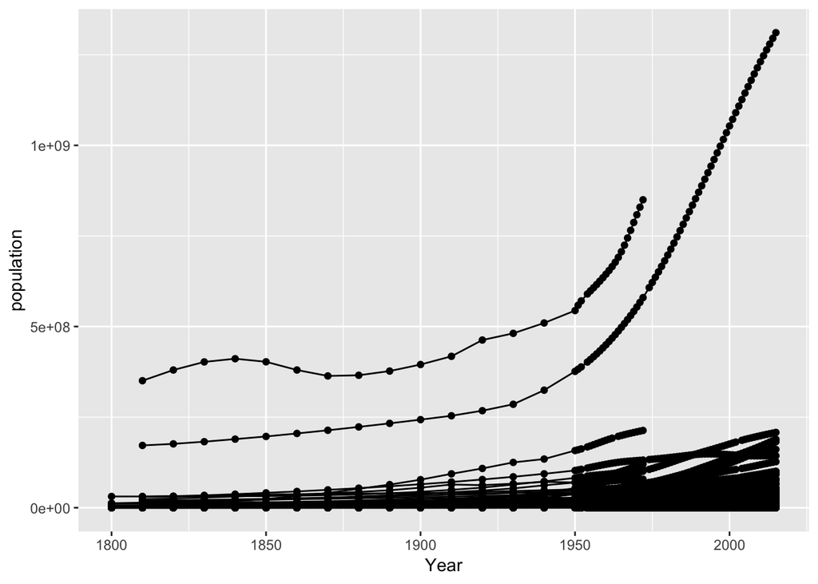

```r
# draw a line chart of population change by year and grouped by country.
library(ggplot2)
ggplot(newdata, aes(x = Year, y = population,group=Country))+
  geom_line()+
  geom_point()
```

### find out which country has the largest and second largest population

```r
# identify which row in dataframe
which.max(newdata$population)
```

```
## [1] 5423
```

```r
# extract the exact row and find the country is India
newdata[5423,]
```

```
##       Country Year life population income     region
## 16918   India 2015 66.8 1311050527   5903 South Asia
```

```r
# create new data without india
withoutIndia <-subset(newdata,Country!="India")
# find out China has the second largest population
withoutIndia[which.max(withoutIndia$population) ,]
```

```
##      Country Year life population income              region
## 7607   China 1972 61.1  849787991    843 East Asia & Pacific
```

## 3.2 the range of global life span has increase over the years from 25-40 years in 1800, to 50-85 years in 2000. People tend to live longer in general.

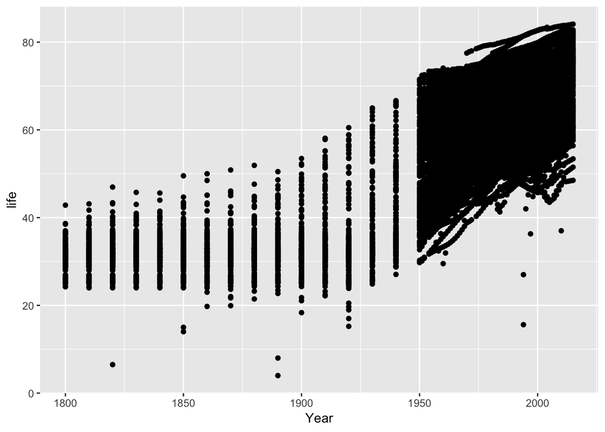

```r
# draw a scatterplot of life span by year
ggplot(data = newdata) +
  geom_point(mapping = aes(x = Year, y = life))
```

### By comparing means of life span across different continents, we find that Europe and Central Asia is doing the best, and South Asia and Sub-Saharan African are doing the worst over the years.

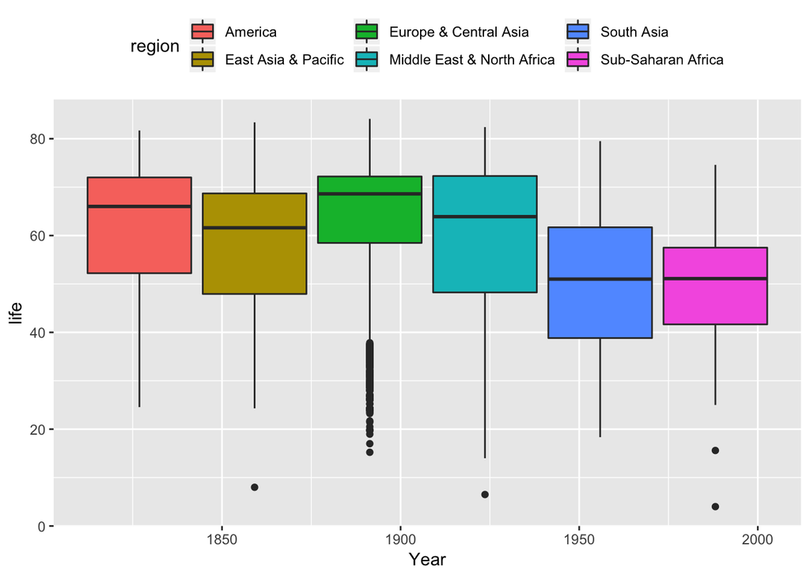

```r
# draw the boxplot
ggplot(newdata, aes(x=Year, y = life, fill=region))+
  geom_boxplot() +
  theme(legend.position="top")
```

## 3.3 Income increase by year in general. Middle East& North Africa, East Asia& Pacific and Eurip & central Asia are leading the run.

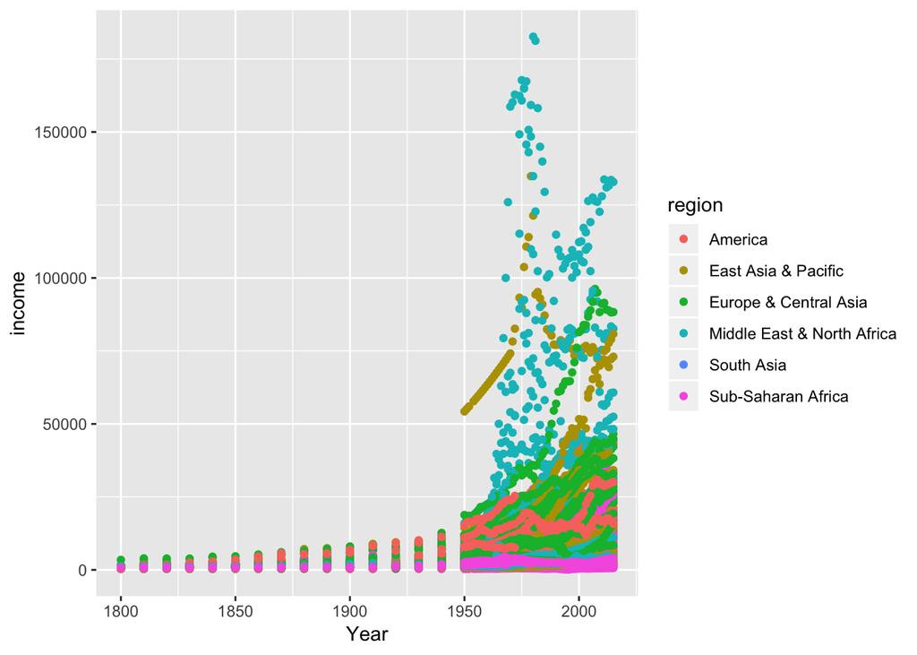

```r
# draw scatterplot of income by year and continents
ggplot(newdata, aes(x = Year, y = income,group=region))+
  geom_point(aes(color = region))
```

### take a closer look at data from 1950 to 2015

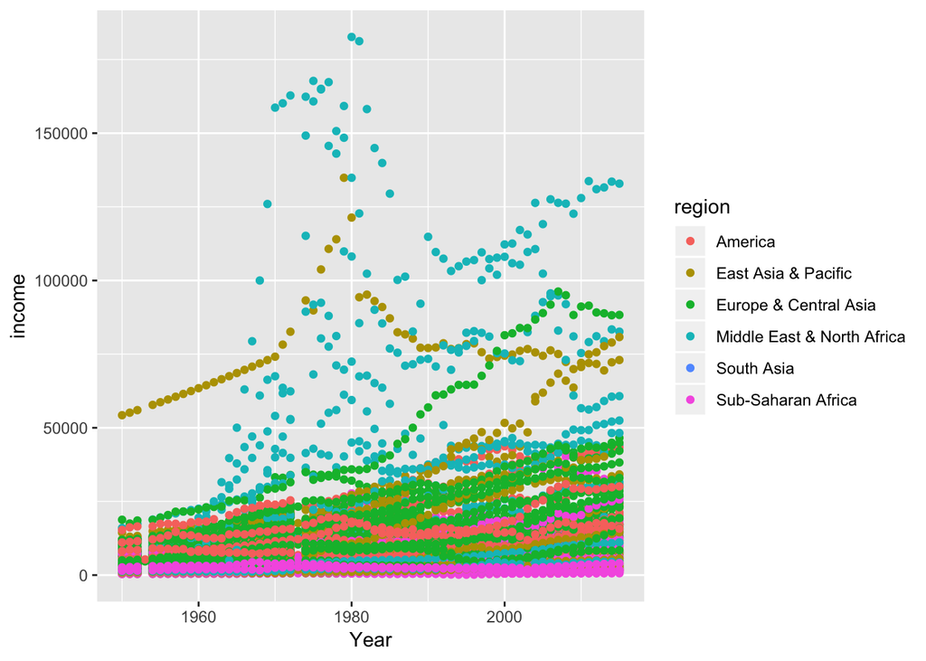

```r
ggplot(newdata, aes(x = Year, y = income,group=region))+
  xlim(1950,2015)+
  geom_point(aes(color = region))
```

# 4. CONCLUSION

### In sum, based on the grahps shown above, we can see that as time pass by, human warefare around the world has increase gradually, though the development speed vary by different continents. For popoluation, China and India have the most pupulation increase, for life span, Europe and America have the longest, and for income, Middle East& North Africa, East Asia& Pacific and Eurip & central Asia are leading the run.

# html link: http://rpubs.com/Aprilmeow/468804